# MY472_assignment_final

202018227

20/12/2023

[Github repo](https://github.com/psyvesw/MY472_final_assignment.git)

# 1. Introduction

[figure not shown]

Stop and Search in UK

The UK’s stop-and-search procedure, which empowers police to search individuals suspected of possessing illegal items, faces scrutiny over potential profiling biases. These biases may pivot on personal characteristics—race, ethnicity, age—over concrete evidence, compromising the fairness of law enforcement. Therefore, this study aims to investigate profiling biases within London’s stop-and-search operations over a year.

## 1.1 Methodology

To discern if disparities in stop-and-search rates (SSR) are indicative of bias or reflective of legitimate policing patterns, the study employs a two-stage analytical framework:

**1. Pattern Identification:**  
Quantitative assessment of SSR across different demographic groups, paired with an analysis of the types of search objects.  
**2. Bias Confirmation:**

**a. Comparative Analysis:**  
- *Population Comparison*: Evaluating whether SSR are proportional to the demographic composition of London.  
- *Arrest Rate Analysis*: Comparing SSR to arrest statistics to determine if certain demographics are being searched more frequently without a corresponding increase in criminal activity.

**b. Benchmarks:**  
- Ratios > 1 when contrasting search rates with population or arrest statistics signal potential over-targeting beyond what demographic or criminal activity data would rationalize.

**c. Outcome Analysis:**  
- If certain groups have a higher frequency of searches but a lower rate of positive outcomes (‘hits’), this could imply a discrepancy between suspicion and actual criminal activity, signaling biase.

# 2. Data

The core of this analysis rests on stop-and-search records from London, collected from 31 November 2022 to 31 October 2023 via API scraping from [data.police.uk](https://data.police.uk/docs/method/stops-street/). Complementary demographic insights were derived from [the 2021 Census data from England and Wales](https://www.ons.gov.uk/peoplepopulationandcommunity/culturalidentity/ethnicity/bulletins/ethnicgroupenglandandwales/census2021) and [the Greater London Authority (2019)](https://data.london.gov.uk/social-evidence-base/population/). Arrest statistics up to March 2022 were obtained from [the UK government’s official repository](https://www.gov.uk/government/statistics/police-powers-and-procedures-stop-and-search-and-arrests-england-and-wales-year-ending-31-march-2022).

## 2.1 Stop and Search Data

- Vehicle-only searches were removed.
- Cases lacking both self-defined and officer-defined ethnicity were omitted.
- In instances of unreported self-defined ethnicity, officer-defined ethnicity was utilized.

Cleaned Stop and Search Data for Inner London in Year Ending 31 October 2023

| Age | Gender | Ethnicity | Broad Ethnicity | Object of Search | Outcome | Combined Ethnicity |
| --- | --- | --- | --- | --- | --- | --- |
| 25-34 | Male | White Other | White | Controlled drugs | TRUE | White - Any other White background |
| 18-24 | Unknown | Mixed White and Black African | White | Controlled drugs | FALSE | Mixed/Multiple ethnic groups - White and Black African |
| Unknown | Male | Other | Other | Offensive weapons | FALSE | Other ethnic group - Not stated |
| 18-24 | Male | Other | Other | Anything to threaten or harm anyone | FALSE | Other ethnic group - Any other ethnic group |
| 10-17 | Unknown | Black Other | Black | Anything to threaten or harm anyone | FALSE | Black/African/Caribbean/Black British - Any other Black/African/Caribbean background |
| 10-17 | Male | Mixed Other | Mixed | Anything to threaten or harm anyone | FALSE | Mixed/Multiple ethnic groups - Any other Mixed/Multiple ethnic background |
| 10-17 | Male | Other | Other | Anything to threaten or harm anyone | FALSE | Other ethnic group - Any other ethnic group |

## 2.2 Structure of Cleaned Additional Datasets

### 2.2.1 Ethnic group, England and Wales: Census 2021

London Ethnicity Distribution 2021

| Broad Ethnicity | Geography | Percentage |
| --- | --- | --- |
| Asian | London | 20.7 |
| Black | London | 13.5 |
| Mixed | London | 5.7 |
| Other | London | 6.3 |
| White | London | 53.8 |

### 2.2.2 London’s diverse population from Greater London Authority (2019)

London Age Distribution 2019

| Age | Number | Population Percentage |
| --- | --- | --- |
| 10-17 | 1250 | 14 |
| 18-24 | 962 | 11 |
| 25-34 | 1689 | 19 |
| over 34 | 4581 | 51 |
| under 10 | 624 | 7 |

London Gender Distribution 2019

| Gender | Number | Population Percentage |
| --- | --- | --- |
| Male | 4554 | 50 |
| Female | 4552 | 50 |

### 2.2.3 Arrest summary tables: year ending 31 March 2022

Number of Persons Arrested by Ethnic Group 2006 to 2021

| Broad Ethnicity | Arrest Number | Arrest Rate |
| --- | --- | --- |
| White | 438527 | 78 |
| Black | 51018 | 9 |
| Asian | 42028 | 7 |
| Mixed | 20030 | 4 |
| Other | 9801 | 2 |
| Unknown | 101632 | NA |
| Total | 663036 | 100 |

Arrest Rates by Age Groups from 2006 to 2021

| Age | Arrest Rate |
| --- | --- |
| under 10 | 0.0041221 |
| 10-17 | 14.1562749 |
| 18-20 | 12.5836588 |
| over 21 | 73.1334351 |
| Unknown | 0.1225091 |

Arrest Rates by Gender from 2006 to 2021

| Gender | Arrest Rate |
| --- | --- |
| Male | 84.1468005 |
| Female | 15.8281054 |
| Other | 0.0000000 |
| Unknown | 0.0250941 |

# 3. Analysis

## 3.1 Ethnic Disparities

### 3.1.1 Disproportionate SSR

> Individuals in the ‘Other’ category experience the highest rate at 34.31%, with ‘White British’ at 19.51%, and ‘Black Other’ at 11.34%. These figures, compared to the broad ethnic group rates—‘Other’ at 35.94%, ‘White’ at 33.09%, and ‘Black’ at 23.71%—demonstrate a skewed application towards certain groups.

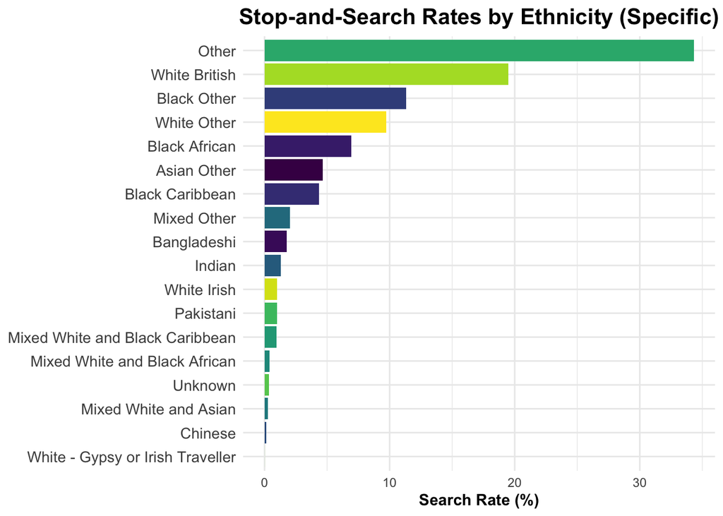

Stop and Search Rate Across Different Ethnicities (Broad)

| Broad Ethnicity | Number of People | Stop and Search Rate |
| --- | --- | --- |
| Asian | 2467 | 5.144299 |
| Black | 11369 | 23.707148 |
| Mixed | 1017 | 2.120694 |
| Other | 17235 | 35.939194 |
| White | 15868 | 33.088665 |

### 3.1.2 Bias in Search Objectives

> ‘Other’ are primarily searched for ‘Offensive weapons’ and ‘Psychoactive substances’, while ‘White’ are more often searched for ‘Controlled drugs’ and ‘Criminal damage’, suggesting potential bias in the perceived association between ethnicity and certain crimes.

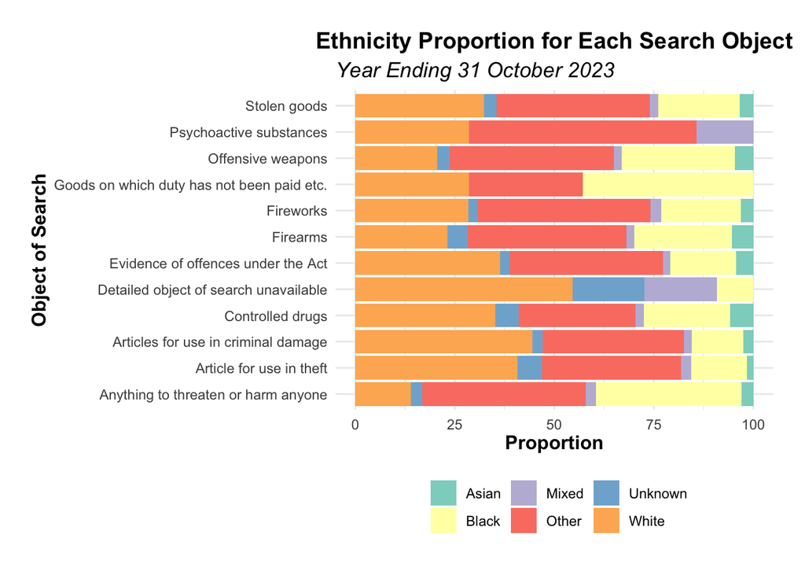

### 3.1.3 Population and Arrest Rate Comparisons

> The ‘Other’ and ‘Black’ categories show overrepresentation in SSR relative to their population sizes, with ratios of 5.70 and 1.76, respectively, contrasting with the ‘Asian’ category’s underrepresentation at 0.25. Additionally, the disproportionate SSR to arrests for ‘Other’ (17.97) and ‘Black’ (2.63) ethnicities suggest a disparity not justified by arrest records.

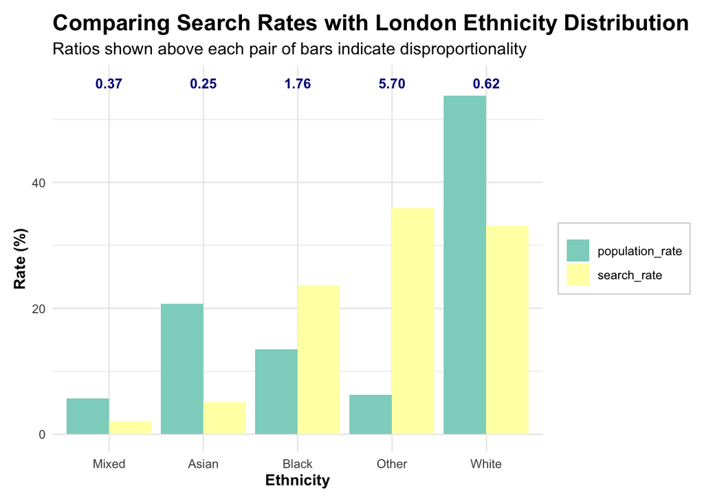

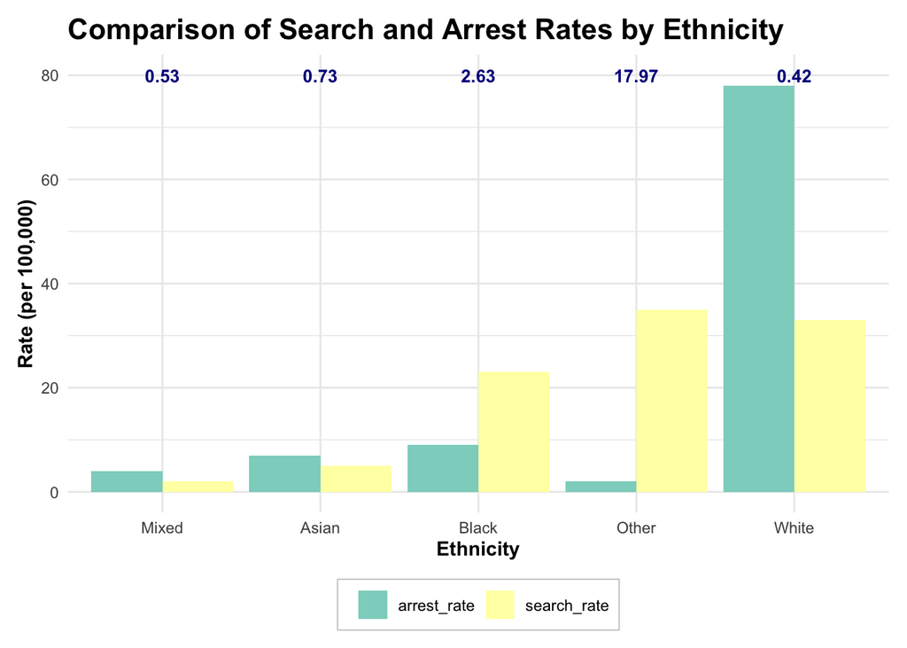

### 3.1.4 Outcome Analysis

> The ‘Other’ group exhibits a low hit rate of 29.51% against their SSR of 35.94%, and this hit rate is relatively low compared to other ethnicities, suggesting that a high number of searches do not lead to evidence of wrongdoing.

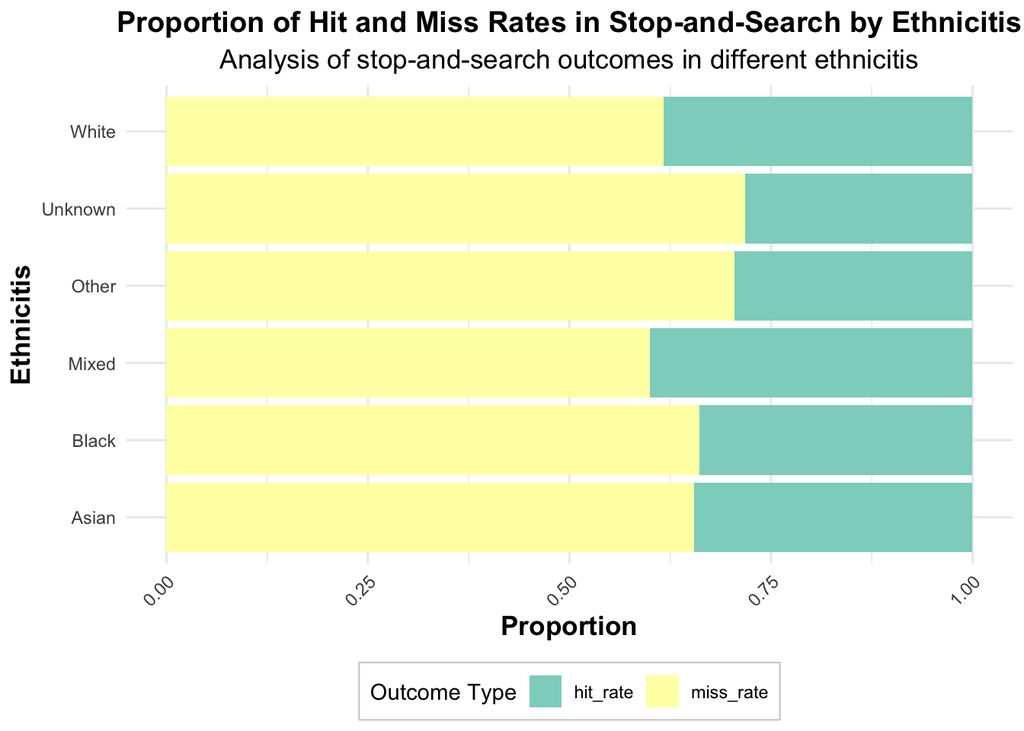

Comparison of Stop-and-Search Rate and Hit Rate by Ethnicity

| Broad Ethnicity | Search Rate | Hit Rate | Ratio |
| --- | --- | --- | --- |
| Asian | 5.144299 | 34.57944 | 0.1487676 |
| Black | 23.707148 | 33.91456 | 0.6990257 |
| Mixed | 2.120694 | 40.00000 | 0.0530173 |
| Other | 35.939194 | 29.51442 | 1.2176827 |
| White | 33.088665 | 38.36672 | 0.8624315 |

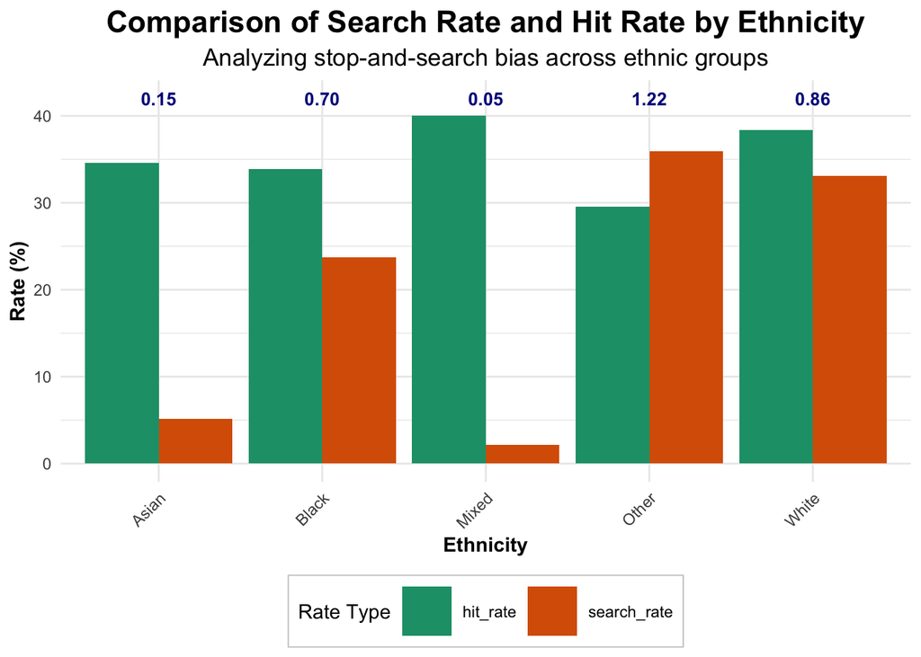

## 3.2 Age Disparities

### 3.2.1 Disproportionate SSR

> Individuals aged 18-24 and over 34 are most frequently subjected to stop-and-search at rates of 22.84% and 24.60%, respectively, with the 10-17 age group also facing a notable rate of 19.42%.

Stop and Search Rate Across Different Age Groups

| Age | Number of Poeple | Search Rate |
| --- | --- | --- |
| 10-17 | 9756 | 19.42150 |
| 18-24 | 11472 | 22.83758 |
| 25-34 | 8770 | 17.45864 |
| Unknown | 7864 | 15.65505 |
| over 34 | 12359 | 24.60335 |

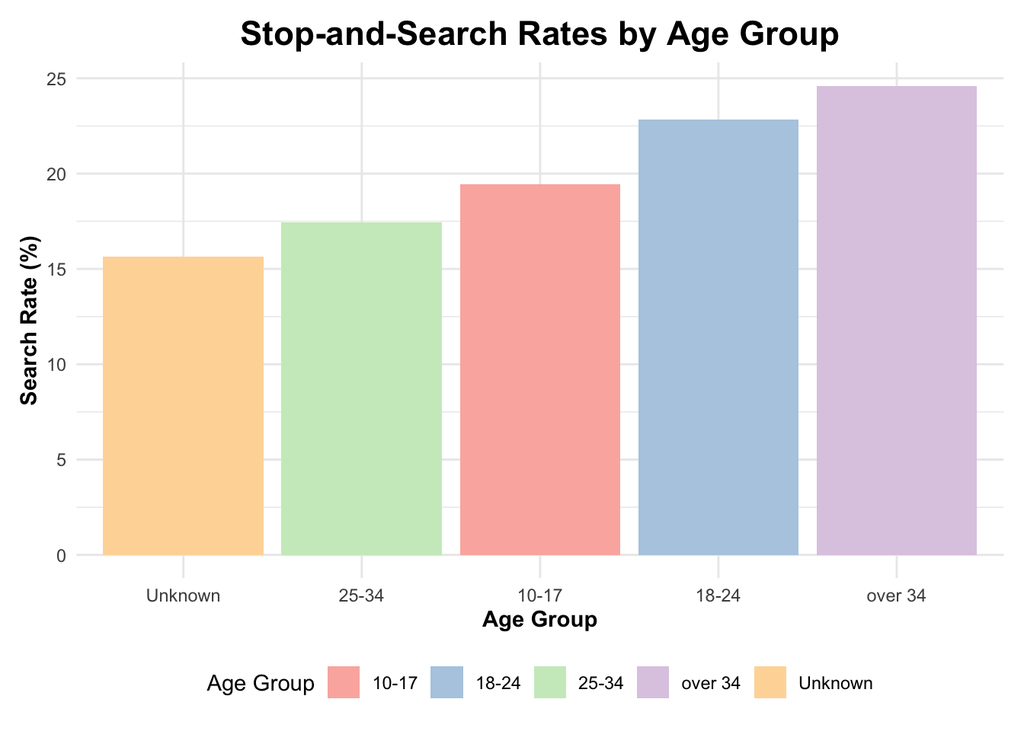

### 3.2.2 Bias in Search Objectives

> Teenagers (10-17) and young adults (18-24) more often searched for potentially harmful items, and those over 34 searched more for controlled drugs, hinting at age-related assumptions in search motives.

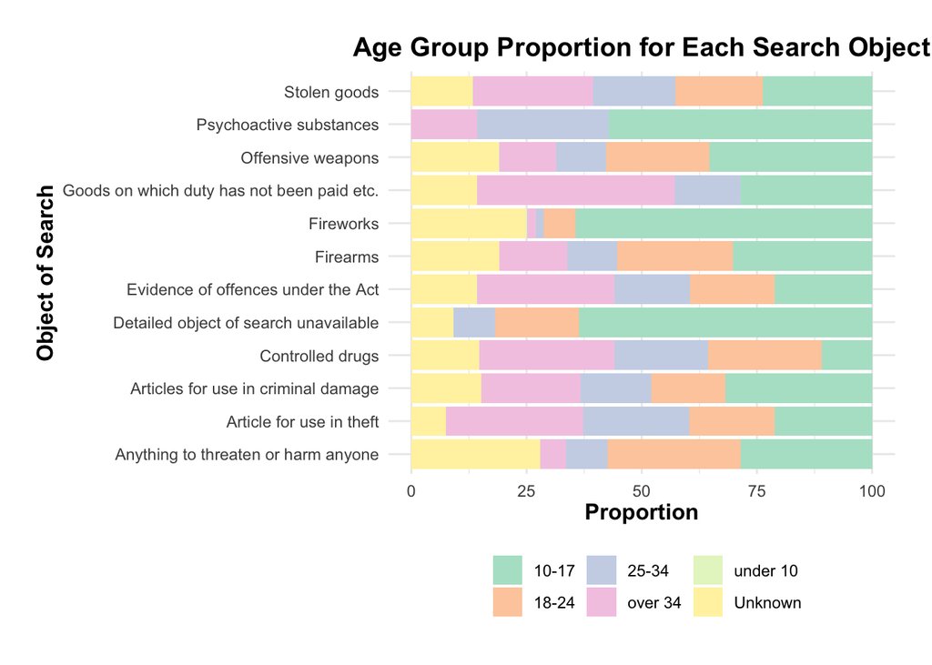

### 3.2.3 Population Rate vs. SSR

> The overrepresentation of the 18-24 age group—with a ratio exceeding 2—suggests that this group is being searched at more than double their expected rate based on population size, potentially pointing to age profiling.

Stop and Search Rate by Age v.s. General Age Distribution in London

| Age | Number of People | Search Percentage | Population Percentage | Ratio |
| --- | --- | --- | --- | --- |
| 10-17 | 9756 | 19.42150 | 14 | 1.3872497 |
| 18-24 | 11472 | 22.83758 | 11 | 2.0761434 |
| 25-34 | 8770 | 17.45864 | 19 | 0.9188759 |
| over 34 | 12359 | 24.60335 | 51 | 0.4824186 |

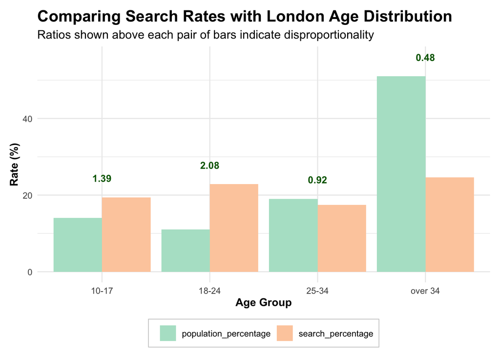

### 3.2.4 Arrest Rates vs. SSR

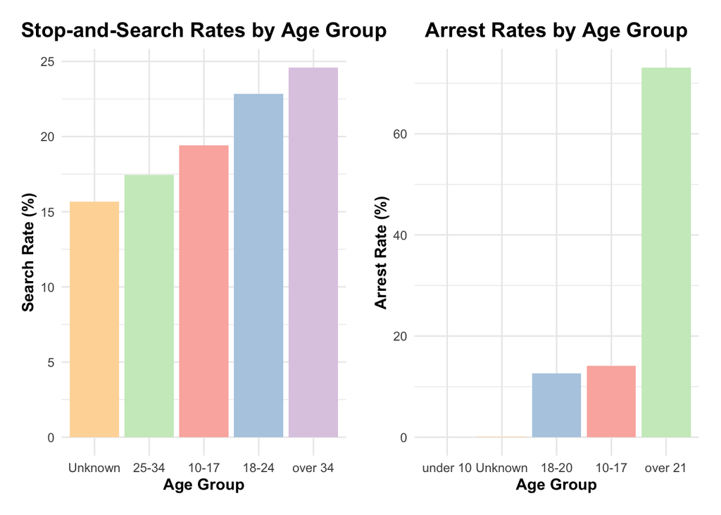

Note. Since the SSR dataset and Arrest Rate dataset have different categories for age groups. two separate visualisations are created for comparison.

### 3.2.5 Outcome Analysis

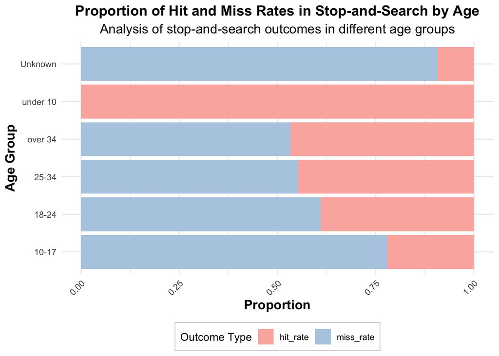

Comparison of Hit and Search Rates by Age Group

| Age | Hit Rate | Search Rate | Ratio |
| --- | --- | --- | --- |
| 10-17 | 22.24335 | 19.42150 | 0.8731373 |
| 18-24 | 39.13333 | 22.83758 | 0.5835837 |
| 25-34 | 44.81086 | 17.45864 | 0.3896074 |
| over 34 | 46.86147 | 24.60335 | 0.5250230 |

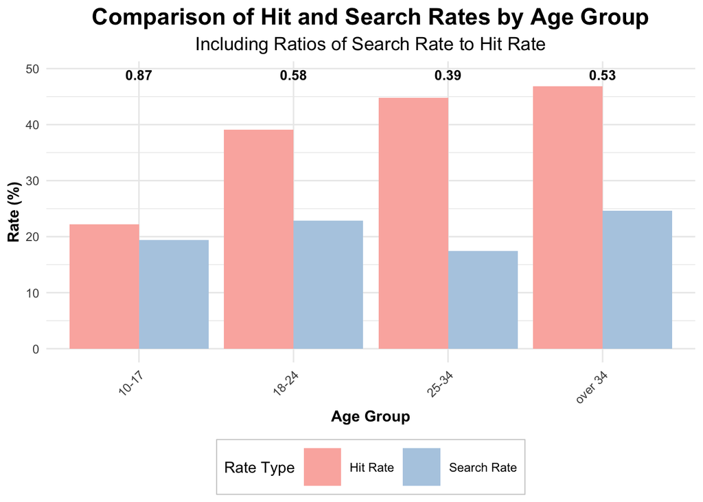

## 3.3 Gender Disparities

### 3.3.1 Disproportionate SSR

> Men encounter an overwhelming SSR of 89.83%, compared to women’s 9.54%, pointing to a significant gender imbalance in search incidents.

Stop and Search Rate Across Gender

| Gender | Number of Poeple | Search Rate |
| --- | --- | --- |
| Female | 4792 | 9.5395457 |
| Male | 45126 | 89.8333765 |
| Other | 50 | 0.0995362 |
| Unknown | 265 | 0.5275417 |

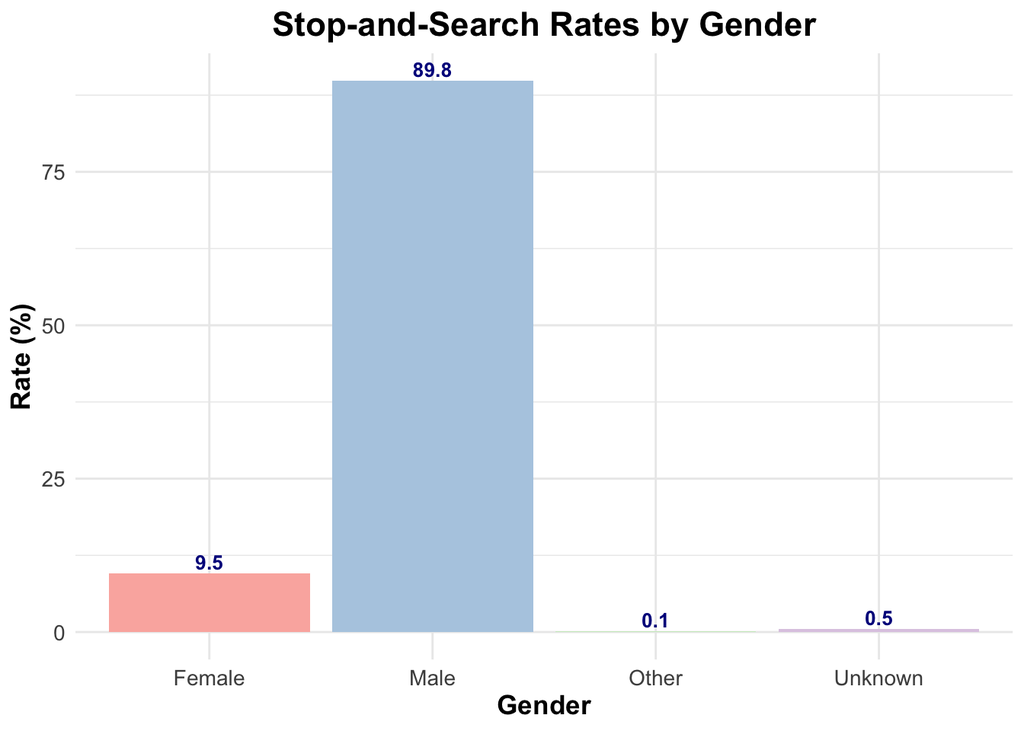

### 3.3.2 Bias in Search Objectives

> Men predominantly face searches for offensive weapons and controlled drugs (over 95% and 88% respectively), while women, less frequently searched, are notably investigated for duty-unpaid goods, suggesting gender-based search presumptions.

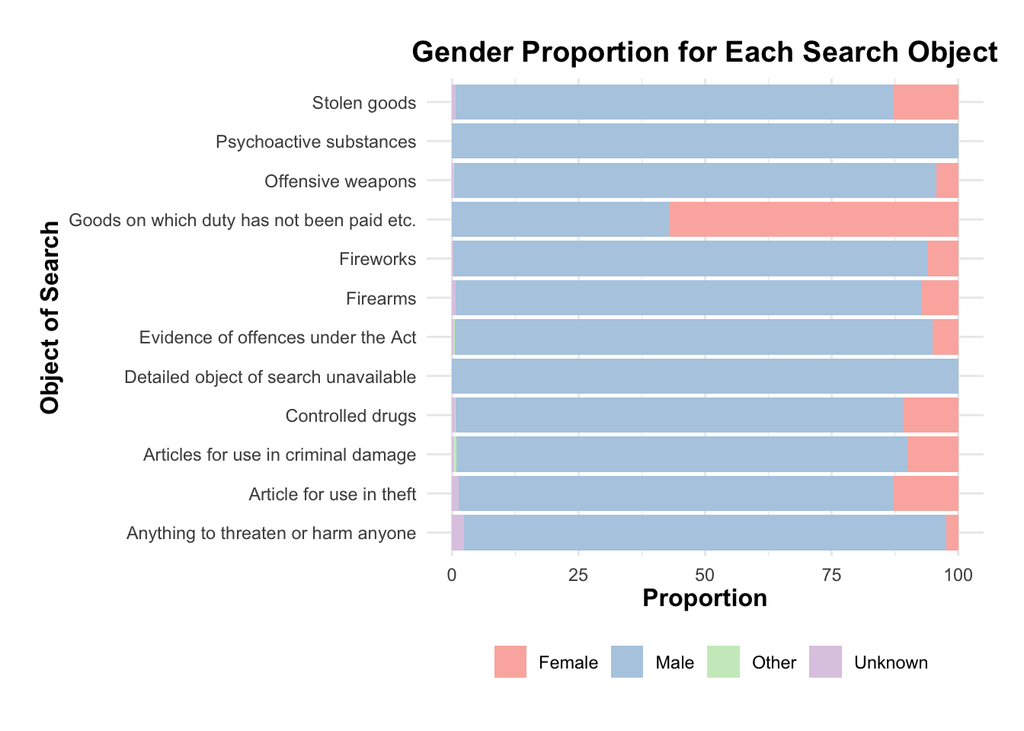

### 3.3.3 Population Rate vs. SSR

> With a roughly equal population distribution, men are subject to stop-and-search almost twice as much as anticipated, indicating potential gender profiling.

Stop and Search Rate by Gender v.s. General Gender Distribution in London

| Gender | Number of Poeple | Search Percentage | Population Percentage | Ratio |
| --- | --- | --- | --- | --- |
| Female | 4792 | 9.599744 | 50 | 0.1919949 |
| Male | 45126 | 90.400256 | 50 | 1.8080051 |

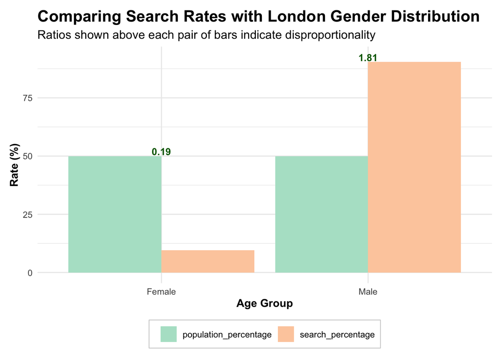

### 3.3.4 Arrest Rate vs. SSR

> While the SSR for men mirrors their arrest rate, the lower SSR for women compared to their arrest rate may signal underuse of stop-and-search for females.

Comparing Stop and Search Rate with Arrest Rates by Gender in UK

| Gender | Arrest Rate | Search Number | Search Rate | Ratio |
| --- | --- | --- | --- | --- |
| Female | 15.8281054 | 4792 | 9 | 0.6026966 |
| Male | 84.1468005 | 45126 | 89 | 1.0675792 |
| Other | 0.0000000 | 50 | 0 | Inf |
| Unknown | 0.0250941 | 265 | 0 | 21.0225350 |

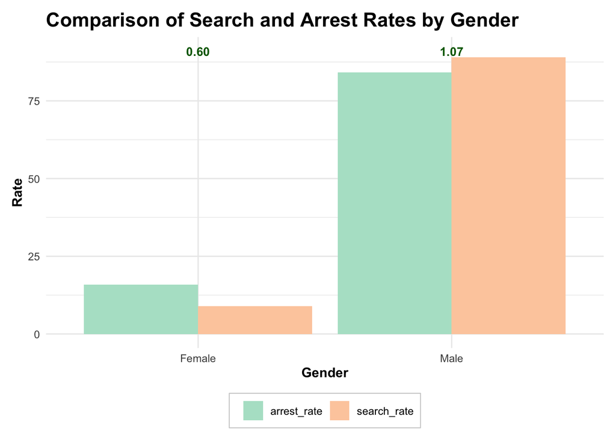

### 3.3.5 Outcome Analysis

> Women, while searched less, exhibit hit rates comparable to men (37.41% versus 33.75%). Meanwhile, men tend to have lower hit rates then SSR (ratio = 2.66), indicating potential bias.

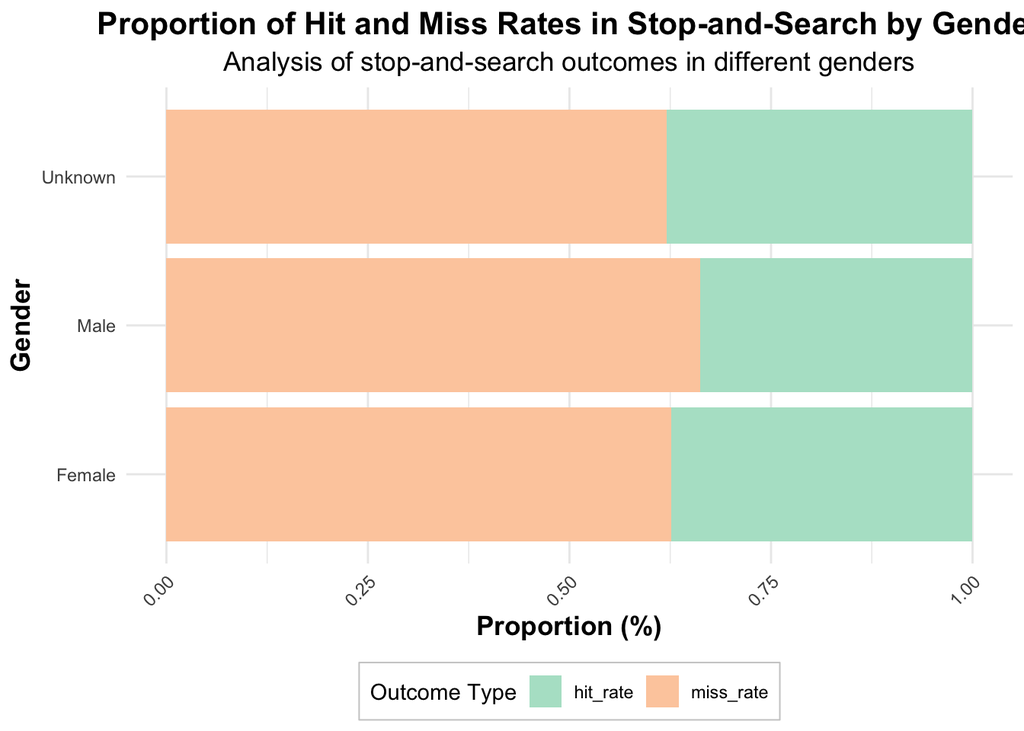

Comparison of Hit and Search Rates by Gender

| Gender | Hit Rate | Search Rate | Ratio |
| --- | --- | --- | --- |
| Female | 37.41176 | 9.5395457 | 0.2549879 |
| Male | 33.75443 | 89.8333765 | 2.6613801 |
| Unknown | 37.93103 | 0.5275417 | 0.0139079 |

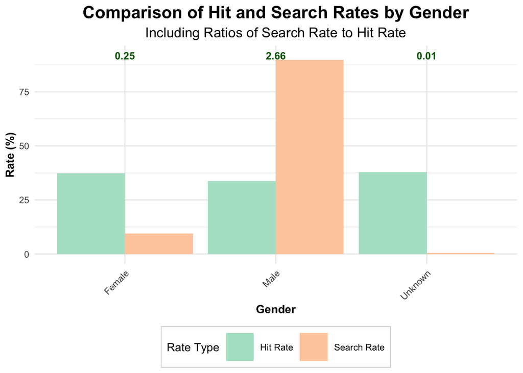

# 4. Conclusion

> Profiling biases are detected in stop-and-search practices by the London police, with disproportionate targeting of ‘Other’ and ‘Black’ ethnic groups, young adults aged 10-24, and men. Such disparities are not fully justified by arrest rates or search effectiveness, suggesting that personal attributes, rather than objective evidence, influence police stop-and-search decision-making.

# 5. Code Appendix

```r
# this chunk contains code that sets global options for the entire .Rmd.
# we use include=FALSE to suppress it from the top of the document, but it will still appear in the appendix.

knitr::opts_chunk$set(echo = FALSE) # actually set the global chunk options.
# we set echo=FALSE to suppress code such that it by default does not appear throughout the document.
# note: this is different from .Rmd default

library(tidyverse)
library(httr)
library(jsonlite)
library(dplyr)
library(tidyr)
library(knitr)
library(kableExtra)
library(DBI)
library(ggplot2)
library(viridis)
library(RColorBrewer)
library(patchwork)
library(scales)
# ___ Stop and Search Data for London in Year Ending 31 October 2023 ___

# ___ Data Access: scrap the stop and search data from 2023-04 to 2023-10 in London using the API ___

# API endpoint and parameters for  London as a custom area
base_url <- "https://data.police.uk/api/stops-street"
london_poly <- "51.631281,0.223716:51.605604,0.073060:51.541012,0.332974:51.296880,0.091089:51.338542,-0.038244:51.287790,-0.118609:51.467672,-0.510495:51.631721,-0.498641:51.691930,-0.148304:51.680473,-0.012827"

# Initialize an empty list to store the data from each month
monthly_data <- list()

# Initialize a counter for indexing the monthly_data list
list_counter <- 1

# Loop through 2023-04 to 2023-10
for (month in 4:10) {
  # Format the month to "YYYY-MM" format
  date_param <- sprintf("2023-%02d", month)

  # Make the API request
  response <- GET(url = base_url, query = list(poly = london_poly, date = date_param))

  # Check if the request was successful
  if (status_code(response) == 200) {
    # Parse JSON response
    month_data <- fromJSON(rawToChar(response$content))
    # Add the month's data to the list using the list_counter for indexing
    monthly_data[[list_counter]] <- month_data
  } else {
    print(paste("Failed to fetch data for month:", month, "Status code:", status_code(response)))
  }

  # Increment the list_counter
  list_counter <- list_counter + 1
}

combined_data <- bind_rows(monthly_data)
# ___ Data Cleaning ___

# Flatten the nested structure in stop_search_data for easier manipulation
stop_search_data <- combined_data %>%
  unnest(outcome_object) %>%
  unnest(location)

# Filter to exclude vehicle searches
stop_search_data <- stop_search_data %>%
  filter(type == "Person search")

# Remove unused columns
stop_search_data <- stop_search_data %>%
  select(-legislation, -involved_person, -outcome, -removal_of_more_than_outer_clothing,
         -id, -name, -operation, -operation_name, -type)

# Recode NA as Unknown
stop_search_data <- stop_search_data %>%
  mutate(
    self_defined_ethnicity = ifelse(is.na(self_defined_ethnicity), "Unknown", self_defined_ethnicity),
    officer_defined_ethnicity = ifelse(is.na(officer_defined_ethnicity), "Unknown", officer_defined_ethnicity),
    age_range = ifelse(is.na(age_range), "Unknown", age_range),
    gender = ifelse(is.na(gender), "Unknown", gender)
  )

# Clean ethnicity data
stop_search_data <- stop_search_data %>%
  mutate(
    combined_ethnicity = ifelse(self_defined_ethnicity == "Unknown", officer_defined_ethnicity, self_defined_ethnicity)
  ) %>%
  # Recode the detailed ethnicity into specific categories
  mutate(Ethnicity = case_when(
    grepl("Bangladeshi", self_defined_ethnicity) ~ "Bangladeshi",
    grepl("Chinese", self_defined_ethnicity) ~ "Chinese",
    grepl("Indian", self_defined_ethnicity) ~ "Indian",
    grepl("Pakistani", self_defined_ethnicity) ~ "Pakistani",
    grepl("Asian/Asian British - Any other", self_defined_ethnicity) ~ "Asian Other",
    grepl("Black/African/Caribbean/Black British - African", self_defined_ethnicity) ~ "Black African",
    grepl("Black/African/Caribbean/Black British - Caribbean", self_defined_ethnicity) ~ "Black Caribbean",
    grepl("Black/African/Caribbean/Black British - Any other", self_defined_ethnicity) ~ "Black Other",
    grepl("Mixed/Multiple ethnic groups - White and Black African", self_defined_ethnicity) ~ "Mixed White and Black African",
    grepl("Mixed/Multiple ethnic groups - White and Black Caribbean", self_defined_ethnicity) ~ "Mixed White and Black Caribbean",
    grepl("Mixed/Multiple ethnic groups - White and Asian", self_defined_ethnicity) ~ "Mixed White and Asian",
    grepl("Mixed/Multiple ethnic groups - Any other", self_defined_ethnicity) ~ "Mixed Other",
    grepl("White - English/Welsh/Scottish/Northern Irish/British", self_defined_ethnicity) ~ "White British",
    grepl("White - Irish", self_defined_ethnicity) ~ "White Irish",
    grepl("White - Any other", self_defined_ethnicity) ~ "White Other",
    grepl("Other ethnic group", self_defined_ethnicity) | self_defined_ethnicity == "Any Other Ethnic Background" ~ "Other",
    grepl("^White$", self_defined_ethnicity) ~ "White British",
    self_defined_ethnicity == "Unknown" ~ "Unknown",
    TRUE ~ self_defined_ethnicity  # Keep original ethnicity if not matched above
  ))

# Categorize each specific ethnicity into a broader group and called it ethnicity_broad
stop_search_data <- stop_search_data %>%
  mutate(ethnicity_broad = case_when(
    grepl("Asian", Ethnicity) ~ "Asian",
    grepl("White", Ethnicity) ~ "White",
    grepl("Black", Ethnicity) ~ "Black",
    grepl("Mixed", Ethnicity) ~ "Mixed",
    Ethnicity == "Other" ~ "Other",
    Ethnicity == "Unknown" ~ "Unknown",
    TRUE ~ "Unknown"  # Catch-all condition to handle NA and any other unclassified cases
  ))

# Rename long column names, remove unused column and reorder columns
stop_search_data <- stop_search_data %>%
  rename(outcome = outcome_linked_to_object_of_search, ethnicity = Ethnicity) %>%
  select(-street, -officer_defined_ethnicity, -self_defined_ethnicity) %>%
  select(age_range, gender, ethnicity, ethnicity_broad, object_of_search, outcome, combined_ethnicity)

# Print the cleaned stop and search data with a heading
stop_search_data %>%
  head(7) %>%
  kable("html",
        col.names = c("Age", "Gender", "Ethnicity", "Broad Ethnicity", "Object of Search", "Outcome", "Combined Ethnicity"),
        caption = "Cleaned Stop and Search Data for Inner London in Year Ending 31 October 2023") %>%
  kable_styling(bootstrap_options = c("striped", "hover"), full_width = T) %>%
  row_spec(0, bold = T, color = "white", background = "lightblue")
```

```r
# ___ Ethnicity General Data ___

# ___ Data Processing and Cleaning___

# Read tables from the census data
uk_ethnicity <- read.csv("data/uk_ethnicity_broad.csv")

# Only required London data
London_ethnicity <- uk_ethnicity %>%
  filter(Geography == "London") %>%
  rename(percentage = `X.`, ethnicity = `Ethnicity`, geography = `Geography`)

# Combine White British and White Other into White
London_ethnicity <- London_ethnicity %>%
  mutate(ethnicity_broad = ifelse(ethnicity %in% c("White British", "White other"), "White", ethnicity)) %>%
  group_by(ethnicity_broad, geography) %>%
  summarize(percentage = sum(percentage), .groups = "drop")

# Display table
London_ethnicity %>%
  kable("html",
        col.names = c("Broad Ethnicity", "Geography", "Percentage"),
        caption = "London Ethnicity Distribution 2021") %>%
  kable_styling(bootstrap_options = c("striped", "hover"), full_width = T) %>%
  row_spec(0, bold = T, color = "white", background = "lightblue")

# ___ Age and Sex General Data ___

# ___ Data Processing and Cleaning___

london_age_sex <- read.csv("data/london_age_sex_distribution.csv")

# Data manipulation
london_age_sex <- london_age_sex %>%
  rename(Percentage = "Per.cent.of.population")

# Create london_sex dataframe
london_sex <- london_age_sex %>%
  filter(Category %in% c("Male", "Female")) %>%
  rename(gender = Category, population_percentage = Percentage)

# Create london_age dataframe
london_age <- london_age_sex %>%
  filter(!Category %in% c("Total", "Gender", "Male", "Female")) %>%
  rename(age_range = Category,
         population_percentage = Percentage)

# Recategorise age ranges to match the format used in stop and search data
london_age <- london_age %>%
  mutate(age_range = case_when(
    age_range == "0-4"   ~ "under 10",
    age_range == "5-15"  ~ "10-17",
    age_range == "16-24" ~ "18-24",   # Assuming that 16-17 should be included in 18-24 as per stop_search_data
    age_range == "25-34" ~ "25-34",
    age_range %in% c("35-49", "50-64", "65-79", "80+") ~ "over 34",
    TRUE ~ "Unknown"                  # Catch-all for any other age ranges
  ))

# Calculate the total number of people in each age range and its corresponding percentage
london_age <- london_age %>%
  group_by(age_range) %>%
  summarise(
    Number = sum(Number),
    population_percentage = sum(population_percentage)
  ) %>%
  ungroup()

london_age %>%
  kable("html",
        col.names = c("Age", "Number", "Population Percentage"),
        caption = "London Age Distribution 2019") %>%
  kable_styling(bootstrap_options = c("striped", "hover"), full_width = T) %>%
  row_spec(0, bold = T, color = "white", background = "lightblue")
london_sex %>%
  kable("html",
        col.names = c("Gender", "Number", "Population Percentage"),
        caption = "London Gender Distribution 2019") %>%
  kable_styling(bootstrap_options = c("striped", "hover"), full_width = T) %>%
  row_spec(0, bold = T, color = "white", background = "lightblue")
# ___ Arrest Summary General Data ___

# ___ Data Processing and Cleaning___

# Read three tables from GOV.UK
uk_arrest_ethnicity<-read.csv("data/uk_arrest_proportion_ethnicity.csv")
uk_arrest_age<-read.csv("data/uk_arrest_age.csv")
uk_arrest_sex<-read.csv("data/uk_arrest_sex.csv")

# Data manipulation
uk_arrest_ethnicity <- uk_arrest_ethnicity %>%
  rename(ethnicity_broad = "Self.defined.ethnicity",
         Arrest_Rate = "Proportion....",
         rate_per1000 = "Arrest.rate.per.1.000.population") %>%
    select(-rate_per1000)

uk_arrest_ethnicity <- uk_arrest_ethnicity %>%
  mutate(ethnicity_broad = case_when(
    ethnicity_broad == "Asian (or Asian British)" ~ "Asian",
    ethnicity_broad == "Black (or Black British)" ~ "Black",
    ethnicity_broad == "Not stated" ~ "Unknown",
    TRUE ~ ethnicity_broad  # Default case to keep other values as is
  )) %>%
  # Remove commas from all numeric columns and convert to integer
  mutate_at(vars(Number:Arrest_Rate), ~as.integer(gsub(",", "", .)))

uk_arrest_age <- uk_arrest_age %>%
  rename("<10" = "Under.101",
         "10-17" = "Aged.10.17",
         "18-20" = "Aged.18.20",
         ">21" = "Aged.21.and.over",
         "Unknown" = "Age.unknown")

uk_arrest_age <- uk_arrest_age %>%
  # Convert Year to an integer
  mutate(Year = as.integer(sub("/.*", "", Year))) %>%
  # Remove commas and convert columns to numeric, handling '-' as NA
  mutate(across(c(`<10`, `10-17`, `18-20`, `>21`, `Unknown`, `Total`),
                ~as.numeric(gsub(",", "", na_if(.,"-")))))

# Sum Total Arrests for Each Age Group Over the Years
total_arrests_by_age <- uk_arrest_age %>%
  summarise(
    under_10 = sum(`<10`, na.rm = TRUE),
    age_10_17 = sum(`10-17`, na.rm = TRUE),
    age_18_20 = sum(`18-20`, na.rm = TRUE),
    over_21 = sum(`>21`, na.rm = TRUE),
    Unknown = sum(Unknown, na.rm = TRUE)
  ) %>%
  gather(key = "age_range", value = "total_arrests")

# Calculate Total Arrests Across All Age Groups
total_arrests_all_ages <- sum(total_arrests_by_age$total_arrests)

# Calculate the Arrest Rate for Each Age Group
arrest_rate_by_age <- total_arrests_by_age %>%
  mutate(
    arrest_rate = total_arrests / total_arrests_all_ages * 100,
    age_range = case_when(
      age_range == "under_10" ~ "under 10",
      age_range == "age_10_17" ~ "10-17",
      age_range == "age_18_20" ~ "18-20",
      age_range == "over_21" ~ "over 21",
      age_range == "Unknown" ~ "Unknown"
    )
  ) %>%
  select(age_range, arrest_rate)

uk_arrest_sex <- uk_arrest_sex %>%
  # Convert Year to an integer representing the start year
  mutate(Year = as.integer(sub("/.*", "", Year))) %>%
  # Remove commas and convert numeric columns to integers
  mutate(across(c(Males, Females, Persons), ~as.numeric(gsub(",", "", .)))) %>%
  # Replace 'N/A' with NA and convert Other and Unknown to numeric
  mutate(Other = as.numeric(gsub("N/A", NA, Other)),
         Unknown = as.numeric(gsub("N/A", NA, Unknown)))

# Renaming columns for consistency and clarity
names(uk_arrest_sex) <-c("Year", "Male", "Female", "Other", "Unknown", "Total")
```

```r
# Summarize the total number of arrests by gender across all years
gender_arrest_totals <- uk_arrest_sex %>%
  summarise(
    Male = sum(Male, na.rm = TRUE),
    Female = sum(Female, na.rm = TRUE),
    Other = sum(Other, na.rm = TRUE),
    Unknown = sum(Unknown, na.rm = TRUE)
  )

# Transpose the dataframe and convert it into a long format
arrest_rate_by_sex <- gender_arrest_totals %>%
  pivot_longer(cols = everything(), names_to = "gender", values_to = "arrests")

# Calculate the total number of arrests
total_arrests <- sum(arrest_rate_by_sex$arrests, na.rm = TRUE)

# Calculate arrest rates by gender
arrest_rate_by_sex <- arrest_rate_by_sex %>%
  mutate(arrest_rate = (arrests / total_arrests) * 100) %>%
  select(-arrests)
# Display these three tables
uk_arrest_ethnicity %>%
  kable("html",
        col.names = c("Broad Ethnicity", "Arrest Number", "Arrest Rate"),
        caption = "Number of Persons Arrested by Ethnic Group 2006 to 2021") %>%
  kable_styling(bootstrap_options = c("striped", "hover"), full_width = T) %>%
  row_spec(0, bold = T, color = "white", background = "lightblue")
arrest_rate_by_age %>%
  kable("html",
        col.names = c("Age", "Arrest Rate"),
        caption = "Arrest Rates by Age Groups from 2006 to 2021") %>%
  kable_styling(bootstrap_options = c("striped", "hover"), full_width = T) %>%
  row_spec(0, bold = T, color = "white", background = "lightblue")
arrest_rate_by_sex %>%
  kable("html",
        col.names = c("Gender", "Arrest Rate"),
        caption = "Arrest Rates by Gender from 2006 to 2021") %>%
  kable_styling(bootstrap_options = c("striped", "hover"), full_width = T) %>%
  row_spec(0, bold = T, color = "white", background = "lightblue")
# ___ Ethnicity Bias Pattern 1 Analysis ___

# Calculate stop-and-search rates by ethnicity
ethnicity_rates <- stop_search_data %>%
  count(ethnicity) %>%
  mutate(rate = n / sum(n) *100)

# Calculate stop-and-search rates by broad ethnicity
ethnicity_broad_rates <- stop_search_data %>%
  filter(ethnicity_broad != "Unknown") %>%
  count(ethnicity_broad) %>%
  mutate(rate = n / sum(n) *100)

# Vertical bar chart of search rates by specific ethnicity
ggplot(ethnicity_rates, aes(x = rate, y = reorder(ethnicity, rate), fill = ethnicity)) +
  geom_bar(stat = "identity") +
  scale_fill_viridis(discrete = TRUE) +
  theme_minimal() +
  theme(
    legend.position = "none",
    axis.text.y = element_text(size = rel(1.2)),
    axis.title.y = element_blank(),
    axis.title.x = element_text(size = rel(1), face = "bold"),
    axis.text.x = element_text(size = rel(1)),
    plot.title = element_text(size = rel(1.4), face = "bold", hjust = 0.5)
  ) +
  labs(title = "Stop-and-Search Rates by Ethnicity (Specific)",
       x = "Search Rate (%)",
       y = "Ethnicity")
ethnicity_broad_rates %>%
  kable("html",
        col.names = c("Broad Ethnicity", "Number of People", "Stop and Search Rate"),
        caption = "Stop and Search Rate Across Different Ethnicities (Broad)") %>%
  kable_styling(bootstrap_options = c("striped", "hover"), full_width = T) %>%
  row_spec(0, bold = T, color = "white", background = "lightblue")

# ___ Ethnicity Bias Pattern 2 Analysis ___

ethnicity_proportion_within_object <- stop_search_data %>%
  filter(object_of_search != "NA") %>%
  count(object_of_search, ethnicity_broad) %>%
  group_by(object_of_search) %>%
  mutate(proportion = n / sum(n) * 100) %>%
  arrange(object_of_search, desc(proportion))

# Visualization
ggplot(ethnicity_proportion_within_object, aes(x = object_of_search, y = proportion, fill = ethnicity_broad)) +
  geom_bar(stat = "identity") +
  coord_flip() +
  scale_fill_brewer(palette = "Set3") +
  labs(
    title = "Ethnicity Proportion for Each Search Object",
    subtitle = "Year Ending 31 October 2023",
    x = "Object of Search",
    y = "Proportion",
    fill = "Ethnicity"
  ) +
  theme_minimal() +
  theme(
    legend.position = "bottom",
    legend.title = element_blank(), # Remove legend title for cleaner look
    axis.title.x = element_text(size = rel(1.1), face = "bold"),
    axis.title.y = element_text(size = rel(1.1), face = "bold"),
    axis.text.x = element_text(size = rel(1), angle = 0, hjust = 0.5, vjust = 0.5),
    axis.text.y = element_text(size = rel(1)),
    plot.title = element_text(size = rel(1.3), face = "bold", hjust = 0.5),
    plot.subtitle = element_text(size = rel(1.2), face = "italic"),
    plot.margin = margin(t = 20, r = 20, b = 20, l = 20) # Add margins for spacing
  )

# ___ Ethnicity Bias Verification 1 ___

comparison_ethnicity <- stop_search_data %>%
  count(ethnicity_broad) %>%
  inner_join(London_ethnicity, by = "ethnicity_broad") %>%
  mutate(search_rate = n / sum(n) * 100,
         population_rate = percentage,
         ratio = search_rate / population_rate) %>%
  select(-percentage)

# Transform the data to long format for visualisation
comparison_ethnicity_long <- comparison_ethnicity %>%
  pivot_longer(
    cols = c(search_rate, population_rate),
    names_to = "rate_type",
    values_to = "rate"
  )

# Create a bar plot with ratio labels
ggplot(comparison_ethnicity_long, aes(x = reorder(ethnicity_broad, rate), y = rate, fill = rate_type)) +
  geom_bar(stat = "identity", position = position_dodge()) +
  scale_fill_brewer(palette = "Set3") +
  geom_text(
    data = comparison_ethnicity,
    aes(x = ethnicity_broad, y = max(search_rate, population_rate) + 2, label = scales::number(ratio, accuracy = 0.01)),
    inherit.aes = FALSE,
    position = position_dodge(width = 0.8),
    vjust = 0.5,
    color = "darkblue", # Changed color for better visibility
    size = 3.5, # Increased text size for readability
    fontface = "bold" # Bold text for emphasis
  ) +
  theme_minimal() +
  labs(
    title = "Comparing Search Rates with London Ethnicity Distribution",
    subtitle = "Ratios shown above each pair of bars indicate disproportionality",
    x = "Ethnicity",
    y = "Rate (%)"
  ) +
  theme_minimal() +
  theme(
    legend.position = "right",
    legend.title = element_blank(), # Remove legend title for cleaner look
    legend.box.background = element_rect(color = "gray80"),
    axis.title.x = element_text(size = rel(1), face = "bold"),
    axis.title.y = element_text(size = rel(1), face = "bold"),
    axis.text.x = element_text(size = rel(1)),
    plot.title = element_text(size = 16, face = "bold"), # Larger, bold title
    plot.subtitle = element_text(size = 12), # Clear subtitle
    plot.margin = margin(t = 10, r = 10, b = 10, l = 10) # Add margins for spacing
  )
```

```r
# ___ Ethnicity Bias Verification 2 ___

comparison_arrest_ethnicity <- merge(uk_arrest_ethnicity, ethnicity_broad_rates, by = "ethnicity_broad")

comparison_arrest_ethnicity <- comparison_arrest_ethnicity %>%
  rename(arrest_number="Number",
         arrest_rate="Arrest_Rate",
         search_rate="rate",
         search_number="n") %>%
  mutate(ratio = search_rate / arrest_rate)

# Clean comparison_arrest_ethnicity
comparison_arrest_ethnicity$arrest_rate[is.na(comparison_arrest_ethnicity$arrest_rate)] <- 0
comparison_arrest_ethnicity$search_rate <- floor(comparison_arrest_ethnicity$search_rate) # Round down search rate

# Ensuring correct data types
comparison_arrest_ethnicity$ethnicity_broad <- as.factor(comparison_arrest_ethnicity$ethnicity_broad)
comparison_arrest_ethnicity$arrest_number <- as.numeric(comparison_arrest_ethnicity$arrest_number)
comparison_arrest_ethnicity$arrest_rate <- as.numeric(comparison_arrest_ethnicity$arrest_rate)
comparison_arrest_ethnicity$search_number <- as.numeric(comparison_arrest_ethnicity$search_number)
comparison_arrest_ethnicity$search_rate <- as.numeric(comparison_arrest_ethnicity$search_rate)

# Reshape data for plotting
comparison_arrest_ethnicity_long <- comparison_arrest_ethnicity %>%
  select(ethnicity_broad, arrest_rate, search_rate) %>%
  pivot_longer(cols = c(arrest_rate, search_rate),
               names_to = "Rate_Type",
               values_to = "Rate")

# Create the plot
ggplot(comparison_arrest_ethnicity_long, aes(x = reorder(ethnicity_broad, Rate), y = Rate, fill = Rate_Type)) +
  geom_bar(stat = "identity", position = position_dodge()) +
  scale_fill_brewer(palette = "Set3") +
  labs(title = "Comparison of Search and Arrest Rates by Ethnicity",
       x = "Ethnicity",
       y = "Rate (per 100,000)",
       fill = "Rate Type") +
  geom_text(
    data = comparison_arrest_ethnicity,
    aes(x = ethnicity_broad, y = max(search_rate, arrest_rate) + 2, label = scales::number(ratio, accuracy = 0.01)),
    inherit.aes = FALSE,
    position = position_dodge(width = 0.8),
    vjust = 0.5,
    color = "darkblue", # Changed color for better visibility
    size = 3.5, # Increased text size for readability
    fontface = "bold" # Bold text for emphasis
  ) +
  theme_minimal() +
  theme(
    axis.title.x = element_text(size = rel(1), face = "bold"),
    axis.title.y = element_text(size = rel(1), face = "bold"),
    axis.text.x = element_text(size = rel(1)),
    legend.position = "bottom",
    legend.box.background = element_rect(color = "gray80"),
    legend.title = element_blank(), # Remove legend title for cleaner look
    plot.title = element_text(size = 16, face = "bold"), # Larger, bold title
    plot.margin = margin(t = 10, r = 10, b = 10, l = 10) # Add margins for spacing
  )
# ___ Ethnicity Bias Verification 3 ___

# Calculate hit rate and miss rate
ethnicity_hit_proportion <- stop_search_data %>%
  filter(outcome %in% c("TRUE", "FALSE")) %>%
  mutate(outcome = recode(factor(outcome), `TRUE` = "Hit", `FALSE` = "Miss")) %>%
  group_by(ethnicity_broad, outcome) %>%
  summarise(count = n(), .groups = "drop") %>%
  pivot_wider(
    names_from = outcome,
    values_from = count,
    values_fill = list(count = 0)
  ) %>%
  mutate(
    total_searches = Hit + Miss,
    hit_rate = Hit / total_searches * 100,
    miss_rate = Miss / total_searches * 100
  )

# Transforming the dataframe into a long format
ethnicity_hit_proportion_long <- ethnicity_hit_proportion %>%
  select(ethnicity_broad, hit_rate, miss_rate) %>%
  pivot_longer(
    cols = c(hit_rate, miss_rate),
    names_to = "outcome_type",
    values_to = "rate"
  )

# Creating a stacked bar chart
ggplot(ethnicity_hit_proportion_long, aes(x = ethnicity_broad, y = rate, fill = outcome_type)) +
  geom_bar(stat = "identity", position = "fill") +  # Stacked bars with relative proportions
  coord_flip() +
  scale_fill_brewer(palette = "Set3", name = "Outcome Type") +  # Color palette for better distinction
  labs(
    title = "Proportion of Hit and Miss Rates in Stop-and-Search by Ethnicitis",
    subtitle = "Analysis of stop-and-search outcomes in different ethnicitis",
    x = "Ethnicitis",
    y = "Proportion",
    fill = "Outcome Type"
  ) +
  theme_minimal() +  # Minimal theme for a clean look
  theme(
    legend.position = "bottom",  # Legend at the bottom for better interpretation
    axis.text.x = element_text(angle = 45, vjust = 1, hjust = 1),  # Slanted x-axis labels for readability
    axis.title.x = element_text(size = rel(1.2), face = "bold"),  # Bold axis titles
    axis.title.y = element_text(size = rel(1.2), face = "bold"),
    plot.title = element_text(size = rel(1.3), face = "bold", hjust = 0.5),  # Emphasized plot title
    plot.subtitle = element_text(size = rel(1.2), hjust = 0.5),  # Clear subtitle
    legend.title.align = 0.5,  # Center-aligned legend title
    legend.box.background = element_rect(color = "gray80")  # Styled legend background for clarity
  )


hit_rates_ethnicity <- ethnicity_hit_proportion %>%
  select(-miss_rate, -total_searches, -Miss)

# Compare hit rate and search rate for each ethnicity group
hit_search_ethnicity <- ethnicity_broad_rates %>%
  inner_join(hit_rates_ethnicity, by = "ethnicity_broad") %>%
  select(ethnicity_broad, rate, hit_rate) %>%
  rename(search_rate = rate) %>%
  mutate(ratio = search_rate / hit_rate)

hit_search_ethnicity %>%
  kable("html",
        col.names = c("Broad Ethnicity", "Search Rate", "Hit Rate", "Ratio"),
        caption = "Comparison of Stop-and-Search Rate and Hit Rate by Ethnicity") %>%
  kable_styling(bootstrap_options = c("striped", "hover"), full_width = T) %>%
  row_spec(0, bold = T, color = "white", background = "lightblue")
# Convert the dataframe from wide to long format for easier plotting
hit_search_ethnicity_long <- hit_search_ethnicity %>%
  pivot_longer(
    cols = c(search_rate, hit_rate),
    names_to = "rate_type",
    values_to = "rate"
  )

# Visualization
ggplot(hit_search_ethnicity_long, aes(x = ethnicity_broad, y = rate, fill = rate_type)) +
  geom_bar(stat = "identity", position = position_dodge()) +
  scale_fill_brewer(palette = "Dark2", name = "Rate Type") +
  labs(
    title = "Comparison of Search Rate and Hit Rate by Ethnicity",
    subtitle = "Analyzing stop-and-search bias across ethnic groups",
    x = "Ethnicity",
    y = "Rate (%)",
    fill = "Rate Type"
  ) +
  geom_text(
    data = hit_search_ethnicity,
    aes(x = ethnicity_broad, y = max(search_rate, hit_rate) + 2, label = scales::number(ratio, accuracy = 0.01)),
    inherit.aes = FALSE,
    position = position_dodge(width = 0.8),
    vjust = 0.5,
    color = "darkblue", # Changed color for better visibility
    size = 3.5, # Increased text size for readability
    fontface = "bold" # Bold text for emphasis
  ) +
  theme_minimal() +
  theme(
    legend.position = "bottom",
    legend.title.align = 0.5,
    legend.box.background = element_rect(color = "gray80"),
    legend.key.size = unit(1, "cm"),  # Increase legend key size for readability
    axis.title.x = element_text(size = rel(1), face = "bold"),
    axis.title.y = element_text(size = rel(1), face = "bold"),
    axis.text.x = element_text(size = rel(1), angle = 45, hjust = 1),
    axis.text.y = element_text(size = rel(1)),
    plot.title = element_text(size = rel(1.5), face = "bold", hjust = 0.5),
    plot.subtitle = element_text(size = rel(1.2), hjust = 0.5)
  ) +
  guides(fill = guide_legend())
```

```r
# ___ Age Bias Pattern 1 Analysis ___

# Calculate stop-and-search rates by age group
age_rates <- stop_search_data %>%
  count(age_range) %>%
  mutate(rate = n / sum(n) * 100) %>%
  filter(age_range != "under 10")

age_rates %>%
  kable("html",
        col.names = c("Age", "Number of Poeple", "Search Rate"),
        caption = "Stop and Search Rate Across Different Age Groups") %>%
  kable_styling(bootstrap_options = c("striped", "hover"), full_width = T) %>%
  row_spec(0, bold = T, color = "white", background = "lightblue")

# Bar chart of search rates by age
ggplot(age_rates, aes(x = reorder(age_range, rate), y = rate, fill = age_range)) +
  geom_bar(stat = "identity") +
  scale_fill_brewer(palette = "Pastel1") +  #
  theme_minimal() +
  theme(
    legend.position = "none",  # Place the legend at the bottom
    axis.text.y = element_text(size = rel(1.2)),  # Increase y-axis label size
    axis.title.y = element_blank(),  # Remove y-axis title for cleaner look
    axis.text.x = element_text(size = rel(1.1)),  # Increase x-axis label size
    plot.title = element_text(size = rel(1.5), face = "bold", hjust = 0.5),  # Style the plot title
    legend.title = element_blank()  # Remove legend title
  ) +
  labs(title = "Stop-and-Search Rates by Age Group",
       x = "Age Group",
       y = "Search Rate (%)",
       fill = "Age Group")  +
  theme_minimal() +
  theme(
    legend.position = "bottom",
    axis.title.x = element_text(size = rel(1), face = "bold"),
    axis.title.y = element_text(size = rel(1), face = "bold"),
    axis.text.x = element_text(size = rel(1)),
    plot.title = element_text(size = rel(1.5), face = "bold", hjust = 0.5),
    plot.subtitle = element_text(size = rel(1.2)),
    # add margin
    plot.margin = margin(10, 10, 10, 10)
  )

# ___ Age Bias Pattern 2 Analysis ___

age_proportion_within_object <- stop_search_data %>%
  filter(object_of_search != "NA") %>%
  count(object_of_search, age_range) %>%
  group_by(object_of_search) %>%
  mutate(proportion = n / sum(n) * 100) %>%
  arrange(object_of_search, desc(proportion)) %>%
  filter(!is.na(object_of_search))

ggplot(age_proportion_within_object, aes(x = object_of_search, y = proportion, fill = age_range)) +
  geom_bar(stat = "identity") +
  coord_flip() +
  scale_fill_brewer(palette = "Pastel2")  +
  labs(
    title = "Age Group Proportion for Each Search Object",
    x = "Object of Search",
    y = "Proportion",
    fill = "Age Group"
  ) +
  theme_minimal() +
  theme(
    legend.position = "bottom",
    legend.title = element_blank(), # Remove legend title for cleaner look
    axis.title.x = element_text(size = rel(1.1), face = "bold"),
    axis.title.y = element_text(size = rel(1.1), face = "bold"),
    axis.text.x = element_text(size = rel(1), angle = 0, hjust = 0.5, vjust = 0.5),
    axis.text.y = element_text(size = rel(1)),
    plot.title = element_text(size = rel(1.3), face = "bold", hjust = 0.5),
    plot.subtitle = element_text(size = rel(1.2), face = "italic"),
    plot.margin = margin(t = 20, r = 20, b = 20, l = 20) # Add margins for spacing
  )

# ___ Age Bias Verification 1 ___

# Merge london_age with the stop-and-search data
age_search_comparison <- age_rates %>%
  rename(search_percentage = rate) %>%
  left_join(london_age, by = "age_range") %>%
  mutate(ratio = search_percentage / population_percentage) %>%
  select(-Number) %>%
  filter(age_range != "under 10", age_range != "Unknown")

# Transform the data to long format for the bar chart
age_search_comparison_long <- age_search_comparison %>%
  pivot_longer(
    cols = c(search_percentage, population_percentage),
    names_to = "rate_type",
    values_to = "rate"
  )

age_search_comparison %>%
  kable("html",
        col.names = c("Age", "Number of People", "Search Percentage", "Population Percentage", "Ratio"),
        caption = "Stop and Search Rate by Age v.s. General Age Distribution in London") %>%
  kable_styling(bootstrap_options = c("striped", "hover"), full_width = T) %>%
  row_spec(0, bold = T, color = "white", background = "lightblue")

# Visualisation

# Define an offset value for the label position
offset <- 5

# Use the `mutate()` function to create the label_y column with proper max values for each age group
age_search_comparison <- age_search_comparison %>%
  mutate(label_y = pmax(search_percentage, population_percentage, na.rm = TRUE) + offset)

ggplot(age_search_comparison_long, aes(x = reorder(age_range, rate), y = rate, fill = rate_type)) +
  geom_bar(stat = "identity", position = position_dodge()) +
  scale_fill_brewer(palette = "Pastel2") +
  geom_text(
    data = age_search_comparison,
    aes(x = age_range, y = label_y, label = scales::number(ratio, accuracy = 0.01)),
    inherit.aes = FALSE,
    vjust = 0.5,
    color = "darkgreen",
    size = 3.5,
    fontface = "bold"
  ) +
  theme_minimal() +
  labs(
    title = "Comparing Search Rates with London Age Distribution",
    subtitle = "Ratios shown above each pair of bars indicate disproportionality",
    x = "Age Group",
    y = "Rate (%)"
  ) +
  theme_minimal() +
  theme(
    legend.position = "bottom",
    legend.title = element_blank(), # Remove legend title for cleaner look
    legend.box.background = element_rect(color = "gray80"),
    axis.title.x = element_text(size = rel(1), face = "bold"),
    axis.title.y = element_text(size = rel(1), face = "bold"),
    axis.text.x = element_text(size = rel(1)),
    plot.title = element_text(size = 16, face = "bold"), # Larger, bold title
    plot.subtitle = element_text(size = 12), # Clear subtitle
    plot.margin = margin(t = 10, r = 10, b = 10, l = 10) # Add margins for spacing
  )

# ___ Age Bias Verification 2 ___

age_search_rate<- ggplot(age_rates, aes(x = reorder(age_range, rate), y = rate, fill = age_range)) +
  geom_bar(stat = "identity") +
  scale_fill_brewer(palette = "Pastel1") +  #
  theme_minimal() +
  theme(
    legend.position = "none",  # Place the legend at the bottom
    axis.text.y = element_text(size = rel(1.2)),  # Increase y-axis label size
    axis.title.y = element_blank(),  # Remove y-axis title for cleaner look
    axis.text.x = element_text(size = rel(1.1)),  # Increase x-axis label size
    plot.title = element_text(size = rel(1.3), face = "bold", hjust = 0.5),  # Style the plot title
    legend.title = element_blank()  # Remove legend title
  ) +
  labs(title = "Stop-and-Search Rates by Age Group",
       x = "Age Group",
       y = "Search Rate (%)",
       fill = "Age Group")  +
  theme_minimal() +
  theme(
    legend.position = "bottom",
    axis.title.x = element_text(size = rel(1), face = "bold"),
    axis.title.y = element_text(size = rel(1), face = "bold"),
    axis.text.x = element_text(size = rel(1)),
    plot.title = element_text(size = rel(1.3), face = "bold", hjust = 0.5),
    plot.subtitle = element_text(size = rel(1.2)),
    # add margin
    plot.margin = margin(10, 10, 10, 10)
  )
```

```r
age_arrest_rate <- ggplot(arrest_rate_by_age, aes(x = reorder(age_range, arrest_rate), y = arrest_rate, fill = age_range)) +
  geom_bar(stat = "identity") +
  scale_fill_brewer(palette = "Pastel1") +  #
  theme_minimal() +
  theme(
    legend.position = "none",  # Place the legend at the bottom
    axis.text.y = element_text(size = rel(1.2)),  # Increase y-axis label size
    axis.title.y = element_blank(),  # Remove y-axis title for cleaner look
    axis.text.x = element_text(size = rel(1.1)),  # Increase x-axis label size
    plot.title = element_text(size = rel(1.3), face = "bold", hjust = 0.5),  # Style the plot title
    legend.title = element_blank()  # Remove legend title
  ) +
  labs(title = "Arrest Rates by Age Group",
       x = "Age Group",
       y = "Arrest Rate (%)",
       fill = "Age Group")  +
  theme_minimal() +
  theme(
    legend.position = "bottom",
    axis.title.x = element_text(size = rel(1), face = "bold"),
    axis.title.y = element_text(size = rel(1), face = "bold"),
    axis.text.x = element_text(size = rel(1)),
    plot.title = element_text(size = rel(1.3), face = "bold", hjust = 0.5),
    plot.subtitle = element_text(size = rel(1.2)),
    # add margin
    plot.margin = margin(10, 10, 10, 10)
  )

# Combined plot without legend
combined_plot <- age_search_rate + age_arrest_rate + plot_layout(guides = 'collect') & theme(legend.position = "none")

# Display the combined plot
print(combined_plot)

# ___ Age Bias Verification 3 ___

age_hit_miss_rates <- stop_search_data %>%
  filter(outcome %in% c("TRUE", "FALSE")) %>%
  mutate(outcome = recode(factor(outcome), `TRUE` = "Hit", `FALSE` = "Miss")) %>%
  group_by(age_range, outcome) %>%
  summarise(count = n(), .groups = "drop") %>%
  pivot_wider(
    names_from = outcome,
    values_from = count,
    values_fill = list(count = 0)
  ) %>%
  mutate(
    total_searches = Hit + Miss,
    hit_rate = Hit / total_searches * 100,
    miss_rate = Miss / total_searches * 100
  )

# Transforming the dataframe into a long format
age_hit_miss_rates_long <- age_hit_miss_rates %>%
  select(age_range, hit_rate, miss_rate) %>%
  pivot_longer(
    cols = c(hit_rate, miss_rate),
    names_to = "outcome_type",
    values_to = "rate"
  )

# Creating a stacked bar chart
ggplot(age_hit_miss_rates_long, aes(x = age_range, y = rate, fill = outcome_type)) +
  geom_bar(stat = "identity", position = "fill") +  # Stacked bars with relative proportions
  coord_flip() +
  scale_fill_brewer(palette = "Pastel1", name = "Outcome Type") +  # Color palette for better distinction
  labs(
    title = "Proportion of Hit and Miss Rates in Stop-and-Search by Age",
    subtitle = "Analysis of stop-and-search outcomes in different age groups",
    x = "Age Group",
    y = "Proportion",
    fill = "Outcome Type"
  ) +
  theme_minimal() +  # Minimal theme for a clean look
  theme(
    legend.position = "bottom",  # Legend at the bottom for better interpretation
    axis.text.x = element_text(angle = 45, vjust = 1, hjust = 1),  # Slanted x-axis labels for readability
    axis.title.x = element_text(size = rel(1.2), face = "bold"),  # Bold axis titles
    axis.title.y = element_text(size = rel(1.2), face = "bold"),
    plot.title = element_text(size = rel(1.3), face = "bold", hjust = 0.5),  # Emphasized plot title
    plot.subtitle = element_text(size = rel(1.2), hjust = 0.5),  # Clear subtitle
    legend.title.align = 0.5,  # Center-aligned legend title
    legend.box.background = element_rect(color = "gray80")  # Styled legend background for clarity
  )


age_hit_rate <- age_hit_miss_rates %>%
  select(age_range, hit_rate) %>%
  mutate(rate = hit_rate, rate_type = "Hit Rate") %>%
  filter(age_range != "Unknown", age_range != "under 10")

age_search_rate <- age_rates %>%
  select(age_range, rate) %>%
  mutate(rate_type = "Search Rate") %>%
  filter(age_range != "Unknown")

# Combine the data frames
age_combined_long <- bind_rows(age_hit_rate, age_search_rate)

# Group by age_range and calculate the ratio
age_combined <- age_combined_long %>%
  group_by(age_range) %>%
  summarise(
    hit_rate = max(rate[rate_type == "Hit Rate"]),
    search_rate = max(rate[rate_type == "Search Rate"]),
    ratio = search_rate / hit_rate,
    .groups = "drop"
  )

age_combined %>%
  kable("html",
        col.names = c("Age", "Hit Rate", "Search Rate", "Ratio"),
        caption = "Comparison of Hit and Search Rates by Age Group") %>%
  kable_styling(bootstrap_options = c("striped", "hover"), full_width = T) %>%
  row_spec(0, bold = T, color = "white", background = "lightblue")
# Visualization
ggplot(age_combined_long, aes(x = age_range, y = rate, fill = rate_type)) +
  geom_bar(stat = "identity", position = position_dodge()) +
  scale_fill_brewer(palette = "Pastel1", name = "Rate Type") +
  geom_text(
    data = age_combined,
    aes(x = age_range, y = max(hit_rate, search_rate) + 2, label = scales::number(ratio, accuracy = 0.01)),
    inherit.aes = FALSE,
    position = position_dodge(width = 0.8),
    vjust = 0.5,
    color = "black",
    size = 3.5,
    fontface = "bold"
  ) +
  labs(
    title = "Comparison of Hit and Search Rates by Age Group",
    subtitle = "Including Ratios of Search Rate to Hit Rate",
    x = "Age Group",
    y = "Rate (%)",
    fill = "Rate Type"
  ) +
  theme_minimal() +
  theme(
    legend.position = "bottom",
    legend.title.align = 0.5,
    legend.box.background = element_rect(color = "gray80"),
    legend.key.size = unit(1, "cm"),
    axis.title.x = element_text(size = rel(1), face = "bold"),
    axis.title.y = element_text(size = rel(1), face = "bold"),
    axis.text.x = element_text(size = rel(1), angle = 45, hjust = 1),
    axis.text.y = element_text(size = rel(1)),
    plot.title = element_text(size = rel(1.5), face = "bold", hjust = 0.5),
    plot.subtitle = element_text(size = rel(1.2), hjust = 0.5)
  ) +
  guides(fill = guide_legend())

# ___ Gender Bias Pattern 1 Analysis ___

# Calculate stop-and-search rates by ethnicity
gender_rates <- stop_search_data %>%
  count(gender) %>%
  mutate(rate = n / sum(n) *100)
```

```r
gender_rates %>%
  kable("html",
        col.names = c("Gender", "Number of Poeple", "Search Rate"),
        caption = "Stop and Search Rate Across Gender") %>%
  kable_styling(bootstrap_options = c("striped", "hover"), full_width = T) %>%
  row_spec(0, bold = T, color = "white", background = "lightblue")

# Enhanced bar chart for stop-and-search rates by gender
ggplot(gender_rates, aes(x = gender, y = rate, fill = gender)) +
  geom_bar(stat = "identity") +
  scale_fill_brewer(palette = "Pastel1") +
  geom_text(aes(label = scales::number(rate, accuracy = 0.1)),  # Adding value labels
            vjust = -0.3,  # Adjust vertical position of labels
            size = 3.5,  # Text size
            color = "darkblue",
            size = 3.5,
            fontface = "bold") +
  theme_minimal() +
  labs(title = "Stop-and-Search Rates by Gender",
       x = "Gender",
       y = "Rate (%)") +
  theme(
    legend.position = "none",  # Removing the legend for simplicity
    axis.title = element_text(size = rel(1.2), face = "bold"),  # Bold axis titles
    axis.text.x = element_text(size = rel(1.2)),  # Increase x-axis label size
    axis.text.y = element_text(size = rel(1.2)),  # Increase y-axis label size
    plot.title = element_text(size = rel(1.5), face = "bold", hjust = 0.5)  # Bold and centered title
  )

# ___ Gender Bias Pattern 2 Analysis ___

gender_proportion_within_object <- stop_search_data %>%
  filter(object_of_search != "NA") %>%
  count(object_of_search, gender) %>%
  group_by(object_of_search) %>%
  mutate(proportion = n / sum(n) * 100) %>%
  arrange(object_of_search, desc(proportion))

ggplot(gender_proportion_within_object, aes(x = object_of_search, y = proportion, fill = gender)) +
  geom_bar(stat = "identity") +
  coord_flip() +
  scale_fill_brewer(palette = "Pastel1")  +
  labs(
    title = "Gender Proportion for Each Search Object",
    x = "Object of Search",
    y = "Proportion",
    fill = "Gender"
  ) +
  theme_minimal() +
  theme(
    legend.position = "bottom",
    legend.title = element_blank(), # Remove legend title for cleaner look
    axis.title.x = element_text(size = rel(1.1), face = "bold"),
    axis.title.y = element_text(size = rel(1.1), face = "bold"),
    axis.text.x = element_text(size = rel(1), angle = 0, hjust = 0.5, vjust = 0.5),
    axis.text.y = element_text(size = rel(1)),
    plot.title = element_text(size = rel(1.3), face = "bold", hjust = 0.5),
    plot.subtitle = element_text(size = rel(1.2), face = "italic"),
    plot.margin = margin(t = 20, r = 20, b = 20, l = 20) # Add margins for spacing
  )

# ___ Gender Bias Verification 1 ___

# Merge london_age with the stop-and-search data
gender_search_comparison <- stop_search_data %>%
  filter(gender == "Male" | gender == "Female" ) %>%
  count(gender) %>%
  mutate(search_percentage = n / sum(n) * 100) %>%
  left_join(london_sex, by = "gender") %>%
  mutate(ratio = search_percentage / population_percentage) %>%
  select(-Number)

# Transform the data to long format for the bar chart
gender_search_comparison_long <- gender_search_comparison %>%
  pivot_longer(
    cols = c(search_percentage, population_percentage),
    names_to = "rate_type",
    values_to = "rate"
  )

gender_search_comparison %>%
  kable("html",
        col.names = c("Gender"," Number of Poeple", "Search Percentage", "Population Percentage", "Ratio"),
        caption = "Stop and Search Rate by Gender v.s. General Gender Distribution in London") %>%
  kable_styling(bootstrap_options = c("striped", "hover"), full_width = T) %>%
  row_spec(0, bold = T, color = "white", background = "lightblue")
# Define an offset value for the label position
offset <- 2

# Use the `mutate()` function to create the label_y column with proper max values for each age group
gender_search_comparison <- gender_search_comparison %>%
  mutate(label_y = pmax(search_percentage, population_percentage, na.rm = TRUE) + offset)

# Now, use the updated data frame in your plot
ggplot(gender_search_comparison_long, aes(x = reorder(gender, rate), y = rate, fill = rate_type)) +
  geom_bar(stat = "identity", position = position_dodge()) +
  scale_fill_brewer(palette = "Pastel2") +
  geom_text(
    data = gender_search_comparison,
    aes(x = gender, y = label_y, label = scales::number(ratio, accuracy = 0.01)),
    inherit.aes = FALSE,
    vjust = 0.5,
    color = "darkgreen",
    size = 3.5,
    fontface = "bold"
  ) +
  theme_minimal() +
  labs(
    title = "Comparing Search Rates with London Gender Distribution",
    subtitle = "Ratios shown above each pair of bars indicate disproportionality",
    x = "Age Group",
    y = "Rate (%)"
  ) +
  theme_minimal() +
  theme(
    legend.position = "bottom",
    legend.title = element_blank(), # Remove legend title for cleaner look
    legend.box.background = element_rect(color = "gray80"),
    axis.title.x = element_text(size = rel(1), face = "bold"),
    axis.title.y = element_text(size = rel(1), face = "bold"),
    axis.text.x = element_text(size = rel(1)),
    plot.title = element_text(size = 16, face = "bold"), # Larger, bold title
    plot.subtitle = element_text(size = 12), # Clear subtitle
    plot.margin = margin(t = 10, r = 10, b = 10, l = 10) # Add margins for spacing
  )

# ___ Gender Bias Verification 2 ___

comparison_arrest_sex <- merge(arrest_rate_by_sex, gender_rates, by = "gender")

comparison_arrest_sex <- comparison_arrest_sex %>%
  rename(search_rate="rate",
         search_number="n") %>%
  mutate(ratio = search_rate / arrest_rate)

# round down to integer to make it more readable
comparison_arrest_sex$search_rate <- floor(comparison_arrest_sex$search_rate)

# Ensuring correct data types
comparison_arrest_sex$gender <- as.factor(comparison_arrest_sex$gender)
comparison_arrest_sex$arrest_rate <- as.numeric(comparison_arrest_sex$arrest_rate)
comparison_arrest_sex$search_number <- as.numeric(comparison_arrest_sex$search_number)
comparison_arrest_sex$search_rate <- as.numeric(comparison_arrest_sex$search_rate)

comparison_arrest_sex %>%
  kable("html",
        col.names = c("Gender", "Arrest Rate", "Search Number", "Search Rate", "Ratio"),
        caption = "Comparing Stop and Search Rate with Arrest Rates by Gender in UK") %>%
  kable_styling(bootstrap_options = c("striped", "hover"), full_width = T) %>%
  row_spec(0, bold = T, color = "white", background = "lightblue")
# Reshape data for plotting
comparison_arrest_sex_plot <- comparison_arrest_sex %>%
  select(gender, arrest_rate, search_rate, ratio) %>%
  filter(gender == "Female" | gender == "Male")
```

```r
comparison_arrest_sex_long <- comparison_arrest_sex_plot %>%
  pivot_longer(cols = c(arrest_rate, search_rate),
               names_to = "Rate_Type",
               values_to = "Rate")

# Create the plot
ggplot(comparison_arrest_sex_long, aes(x = reorder(gender, Rate), y = Rate, fill = Rate_Type)) +
  geom_bar(stat = "identity", position = position_dodge()) +
  scale_fill_brewer(palette = "Pastel2") +
  labs(title = "Comparison of Search and Arrest Rates by Gender",
       x = "Gender",
       y = "Rate",
       fill = "Rate Type") +
  geom_text(
    data = comparison_arrest_sex_plot,
    aes(x = gender, y = max(search_rate, arrest_rate) + 2, label = scales::number(ratio, accuracy = 0.01)),
    inherit.aes = FALSE,
    position = position_dodge(width = 0.8),
    vjust = 0.5,
    color = "darkgreen", # Changed color for better visibility
    size = 3.5, # Increased text size for readability
    fontface = "bold" # Bold text for emphasis
  ) +
  theme_minimal() +
  theme(
    legend.position = "bottom",
    axis.title.x = element_text(size = rel(1), face = "bold"),
    axis.title.y = element_text(size = rel(1), face = "bold"),
    axis.text.x = element_text(size = rel(1)),
    legend.box.background = element_rect(color = "gray80"),
    legend.title = element_blank(), # Remove legend title for cleaner look
    plot.title = element_text(size = 16, face = "bold"), # Larger, bold title
    plot.margin = margin(t = 10, r = 10, b = 10, l = 10) # Add margins for spacing
  )
# ___ Gender Bias Verification 3 ___

sex_hit_miss_rates <- stop_search_data %>%
  filter(outcome %in% c("TRUE", "FALSE")) %>%
  mutate(outcome = recode(factor(outcome), `TRUE` = "Hit", `FALSE` = "Miss")) %>%
  group_by(gender, outcome) %>%
  summarise(count = n(), .groups = "drop") %>%
  pivot_wider(
    names_from = outcome,
    values_from = count,
    values_fill = list(count = 0)
  ) %>%
  mutate(
    total_searches = Hit + Miss,
    hit_rate = Hit / total_searches * 100,
    miss_rate = Miss / total_searches * 100
  )

# Transforming the dataframe into a long format
sex_hit_miss_rates_long <- sex_hit_miss_rates %>%
  select(gender, hit_rate, miss_rate) %>%
  pivot_longer(
    cols = c(hit_rate, miss_rate),
    names_to = "outcome_type",
    values_to = "rate"
  )

# Creating a stacked bar chart
ggplot(sex_hit_miss_rates_long, aes(x = gender, y = rate, fill = outcome_type)) +
  geom_bar(stat = "identity", position = "fill") +  # Stacked bars with relative proportions
  coord_flip() +
  scale_fill_brewer(palette = "Pastel2", name = "Outcome Type") +  # Color palette for better distinction
  labs(
    title = "Proportion of Hit and Miss Rates in Stop-and-Search by Gender",
    subtitle = "Analysis of stop-and-search outcomes in different genders",
    x = "Gender",
    y = "Proportion (%)",
    fill = "Outcome Type"
  ) +
  theme_minimal() +  # Minimal theme for a clean look
  theme(
    legend.position = "bottom",  # Legend at the bottom for better interpretation
    axis.text.x = element_text(angle = 45, vjust = 1, hjust = 1),  # Slanted x-axis labels for readability
    axis.title.x = element_text(size = rel(1.2), face = "bold"),  # Bold axis titles
    axis.title.y = element_text(size = rel(1.2), face = "bold"),
    plot.title = element_text(size = rel(1.4), face = "bold", hjust = 0.5),  # Emphasized plot title
    plot.subtitle = element_text(size = rel(1.2), hjust = 0.5),  # Clear subtitle
    legend.title.align = 0.5,  # Center-aligned legend title
    legend.box.background = element_rect(color = "gray80")  # Styled legend background for clarity
  )

sex_hit_rate <- sex_hit_miss_rates %>%
  select(gender, hit_rate) %>%
  mutate(rate = hit_rate, rate_type = "Hit Rate")

sex_search_rate <- gender_rates %>%
  select(gender, rate) %>%
  filter(gender != "Other") %>%
  mutate(rate_type = "Search Rate")

# Combine the data frames
sex_combined_long <- bind_rows(sex_hit_rate, sex_search_rate)

# Group by age_range and calculate the ratio
sex_combined <- sex_combined_long %>%
  group_by(gender) %>%
  summarise(
    hit_rate = max(rate[rate_type == "Hit Rate"]),
    search_rate = max(rate[rate_type == "Search Rate"]),
    ratio = search_rate / hit_rate,
    .groups = "drop"
  )

sex_combined %>%
  kable("html",
        col.names = c("Gender", "Hit Rate", "Search Rate", "Ratio"),
        caption = "Comparison of Hit and Search Rates by Gender") %>%
  kable_styling(bootstrap_options = c("striped", "hover"), full_width = T) %>%
  row_spec(0, bold = T, color = "white", background = "lightblue")
# Visualization
ggplot(sex_combined_long, aes(x = gender, y = rate, fill = rate_type)) +
  geom_bar(stat = "identity", position = position_dodge()) +
  scale_fill_brewer(palette = "Pastel2", name = "Rate Type") +
  geom_text(
    data = sex_combined,
    aes(x = gender, y = max(hit_rate, search_rate) + 2, label = scales::number(ratio, accuracy = 0.01)),
    inherit.aes = FALSE,
    position = position_dodge(width = 0.8),
    vjust = 0.5,
    color = "darkgreen",
    size = 3.5,
    fontface = "bold"
  ) +
  labs(
    title = "Comparison of Hit and Search Rates by Gender",
    subtitle = "Including Ratios of Search Rate to Hit Rate",
    x = "Gender",
    y = "Rate (%)",
    fill = "Rate Type"
  ) +
  theme_minimal() +
  theme(
    legend.position = "bottom",
    legend.title.align = 0.5,
    legend.box.background = element_rect(color = "gray80"),
    legend.key.size = unit(1, "cm"),
    axis.title.x = element_text(size = rel(1), face = "bold"),
    axis.title.y = element_text(size = rel(1), face = "bold"),
    axis.text.x = element_text(size = rel(1), angle = 45, hjust = 1),
    axis.text.y = element_text(size = rel(1)),
    plot.title = element_text(size = rel(1.5), face = "bold", hjust = 0.5),
    plot.subtitle = element_text(size = rel(1.2), hjust = 0.5)
  ) +
  guides(fill = guide_legend())

# this chunk generates the complete code appendix.
# eval=FALSE tells R not to run (``evaluate'') the code here (it was already run before).
```